# Midterm Report

Mingrui Li, Siyu Zhai, Youwei Hu and Yuchi Liu

# Introduction

This midterm report summarizes the preliminary findings from a randomized clinical trial evaluating the impact of a modified F75 formula (mF75) compared to the standard F75 in children with severe acute malnutrition. The analysis includes 513 enrolled children, with 258 receiving the modified formula and 255 receiving the standard formula.

# Patient Characteristics

## Demographics and Clinical Conditions

At baseline, demographic and clinical characteristics were well-balanced between treatment arms. The median age across all participants was 16 months, with interquartile ranges similar across groups. Median weight and height were also comparable, with the intervention group weighing 6.45 kg and the control group 6.55 kg. The distribution of mid-upper arm circumference (MUAC), sex, breastfeeding status, and clinical features such as kwashiorkor, oedema, shock, diarrhoea, malaria, and severe pneumonia showed no statistically significant differences between the two groups (all p-values > 0.05), indicating successful randomization.

**Table 1. Baseline Demographic and Clinical Characteristics**

[output not shown]

<sup>1</sup> Median (Q1, Q3); n (%)  
<sup>2</sup> Wilcoxon rank sum test; Pearson’s Chi-squared test

## Visual Summaries of Baseline Comparability

These boxplots visualize the distribution of MUAC and weight, stratified by sex and treatment arm. Both MUAC and weight appear to be similar across groups and sexes, with slight variations. The overlap in medians and interquartile ranges suggests no substantial sex-specific treatment effect differences at baseline.

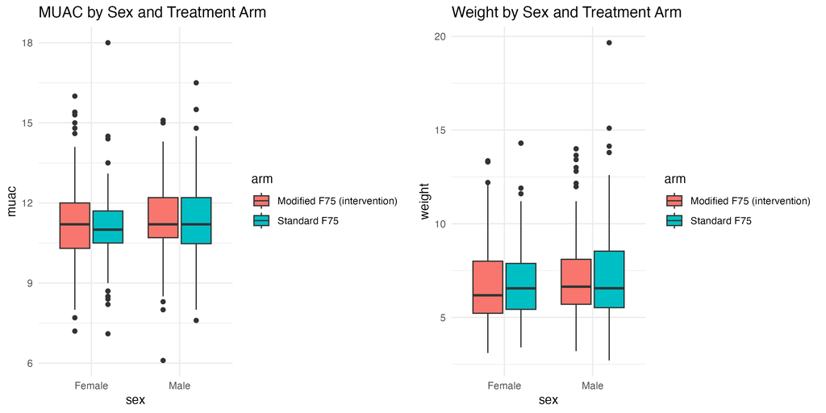

Figure A: MUAC and Weight by Sex and Treatment Arm

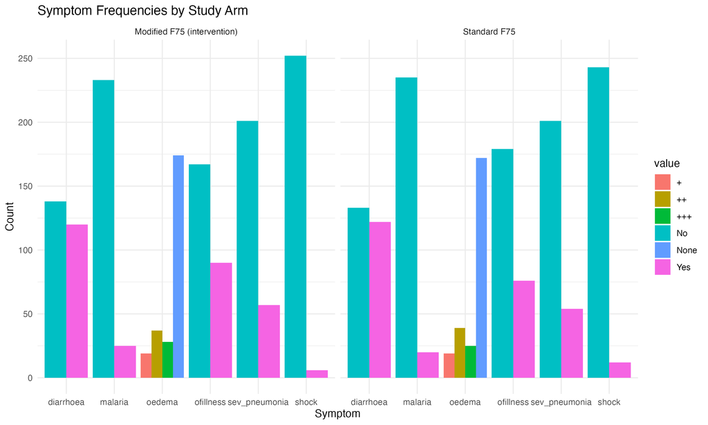

Figure B: Symptom Frequencies by Study Arm

# Outcome Measures

## Days to Stabilization and Discharge Status

**Table 2. Outcome Measures: Days to Stabilization and Discharge Status**

[output not shown]

<sup>1</sup> Mean (SD)  
<sup>2</sup> n (%)

### Figures on Stabilization and Outcome

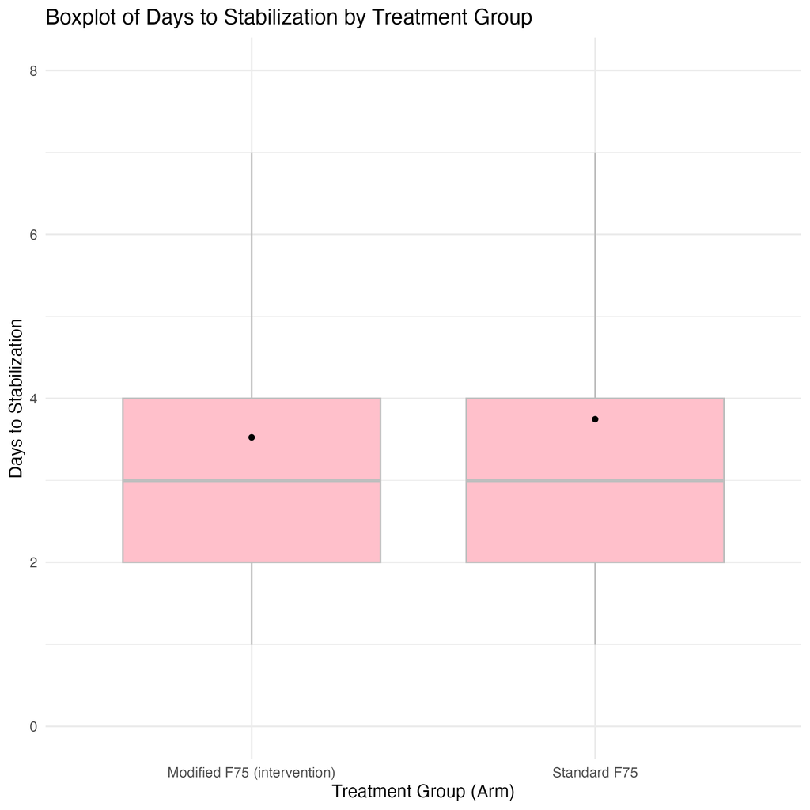

Figure C: Days to Stabilization by Treatment Group

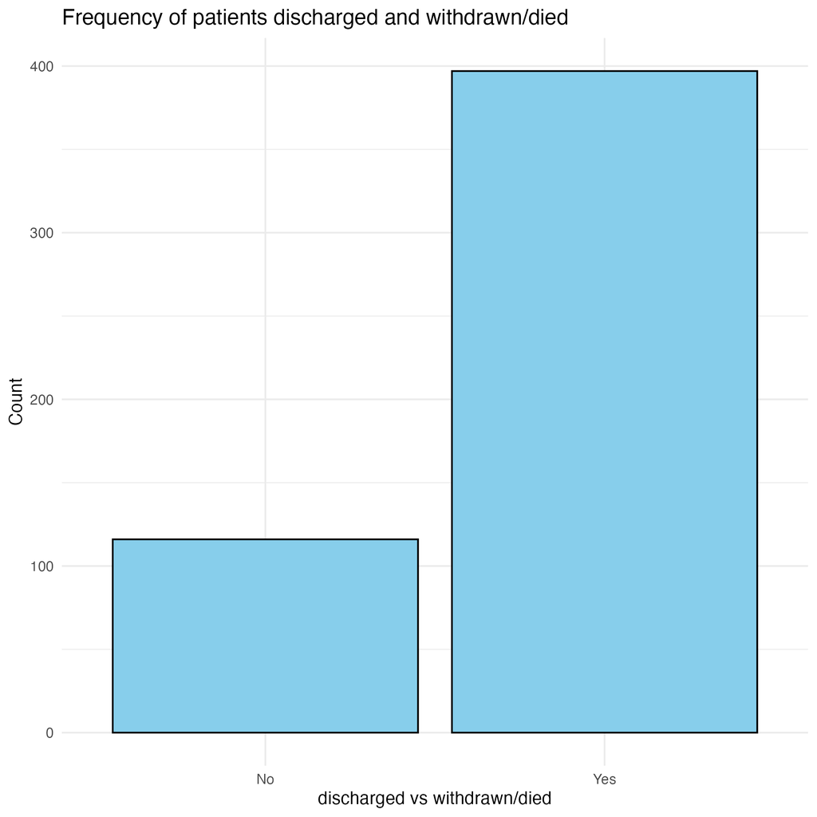

Figure D: Discharged vs. Withdrawn/Dead

# Nutritional Progression

## Summary Statistics

Table 3 presents summary statistics for key nutritional progression indicators:

Table 3: Summary of Nutritional Progression Over Time

| Statistic | days_stable | change_muac | change_weight | change_height | rate_weight_gain |
| --- | --- | --- | --- | --- | --- |
| Min | 1.000000 | -1.8000000 | -3.7000000 | -23.4000000 | -2.2000000 |
| Median | 3.000000 | 0.1000000 | 0.1200000 | 0.1000000 | 0.0333333 |
| Mean | 3.636564 | 0.1890181 | 0.0894684 | 0.0671392 | 0.0458141 |
| Max | 22.000000 | 4.1000000 | 3.2000000 | 5.2000000 | 1.6000000 |
| SD | 2.527130 | 0.6346551 | 0.5228815 | 1.6148324 | 0.2674643 |

This longitudinal plot illustrates positive trends in MUAC and weight from baseline to discharge. The gradual increase reflects nutritional recovery. MUAC appears to improve more consistently than weight, possibly due to fluid retention effects in malnutrition recovery.

## Visualization of Nutritional Trends

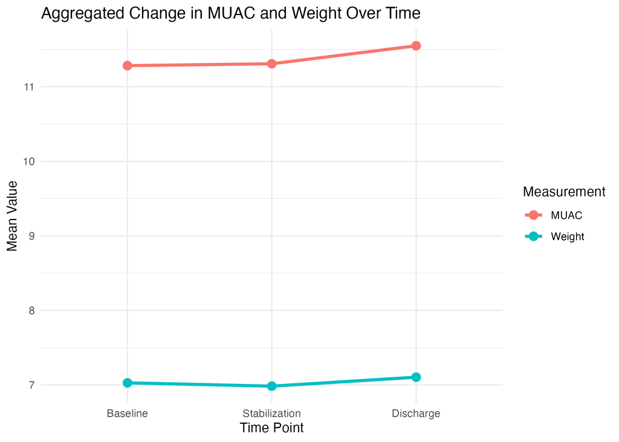

Figure E: Mean MUAC and Weight Over Time

This scatter plot with linear regression suggests a slight negative correlation between rate of weight gain and time to stabilization — children who stabilized faster tended to gain weight more rapidly. While the effect is subtle, it supports the importance of early clinical improvement for nutritional recovery.

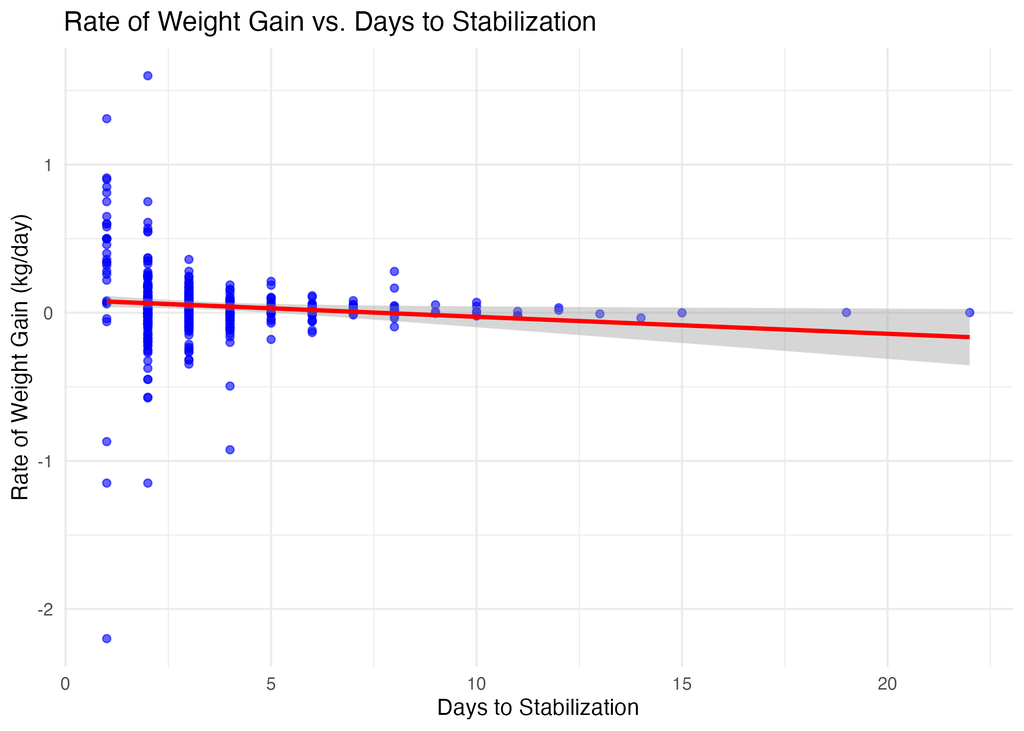

Figure F: Rate of Weight Gain vs. Days to Stabilization

# Conclusion

This interim analysis shows no significant baseline differences between treatment arms. Outcome and progression indicators suggest modest but variable nutritional improvements. Continued monitoring and subgroup analysis are recommended to assess long-term efficacy of the modified formula.